# Time Series Analysis of Fish Passage in Willamette Falls

Kiera Matiska

3/5/2022

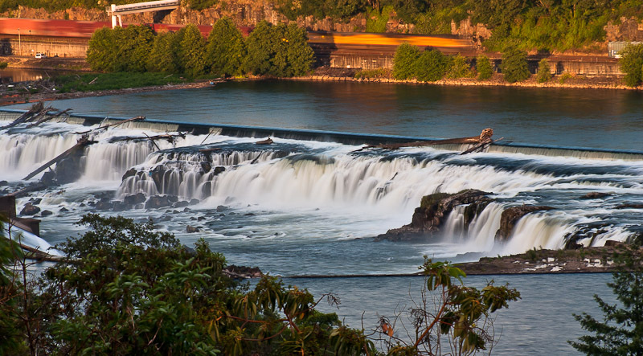

Willamette Falls from the I-205 rest area viewpoint on a July evening; Credit: Bryan Swan

# Overview

Willamette Falls, located on the Willamette River in Clackamas County, Oregon is the largest waterfall by volume in the United States with a 42 foot drop (Northwest Waterfall Survey). The waterfall halts migration patterns of different fish species that use the river, so a fish ladder was implemented to allow for further migration. This code will consist of a time series analysis looking at patterns of ladder use between three fish species. The three species being examined from the data set include Coho Salmon, Jack Coho Salmon, and Steelhead Trout.

```r
knitr::opts_chunk$set(echo = TRUE, message = FALSE, warning = FALSE)

# attach packages
library(tidyverse)
library(here)
library(broom)
library(janitor)
library(lubridate)
library(tsibble)
library(feasts)
library(kableExtra)
library(patchwork)
```

```r
fish <- read_csv(here("data", "willamette_fish_passage.csv")) %>% # read in data
  clean_names()

fish_NA_0 <- replace(fish, is.na(fish), 0) # replace NA values with 0

fish_ts <- fish_NA_0 %>% # create a ts data frame
  mutate(date = mdy(date)) %>%
  as_tsibble(key = NULL, index = date) %>%
  select(project, date, coho, jack_coho, steelhead)
```